# Assignment 4

## Try to submit as an HTML file

Print your name below

Sydney Walker

Import the numpy, matplotlib, and pandas packages

```python
# Write down your answer here:
import numpy as np
import matplotlib.pyplot as plt
import pandas as pandas
```

(a) Create a sequence

```python
# Write your answer here
n=50
list_zero_fifty = list(range(n))
(len(list_zero_fifty))
```

```
50
```

(b) Counting True/False statements in a list

- Create list_ages = [18, 20, 13, 15, 20, 35, 8, 7]
- Create an empty list "list_eligible_voter"
- Use a for-loop without numbering
  - Determine whether the age is $\ge 18$
  - Store the True/False result in "list_eligible_voter"
- Use "np.sum()" to count how many voters are eligible

Hint: Use the "append" function.

```python
# Write your answer here

list_ages = [18, 20, 13, 15, 20, 35, 8, 7]
list_eligible_voter = []

for ages in list_ages:
    eligible_voter = (ages>=18)
    list_eligible_voter.append(eligible_voter)

np.sum(list_eligible_voter)
```

```
4
```

(c) Graphs from multiple datasets

- Create a list with the two "WDI" datasets for 2000, and 2020
- Run a for-loop over each dataset
  - Compute a histogram of "prop_urbanpopulation" for each year
  - Label the title with the name of the dataset

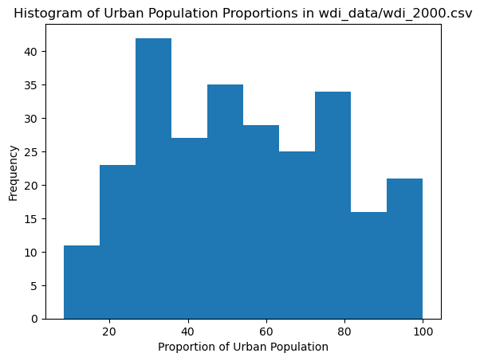

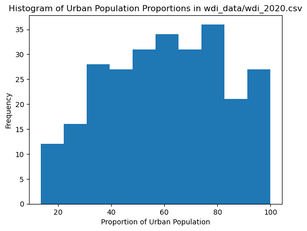

```python
list_datasetnames = ["wdi_data/wdi_2000.csv", "wdi_data/wdi_2020.csv"]

index=0
for wdi_dataset in list_datasetnames:
    dataset = pandas.read_csv(wdi_dataset)
    plt.hist(x= dataset["prop_urbanpopulation"])
    plt.xlabel("Proportion of Urban Population")
    plt.ylabel("Frequency")
    plt.title("Histogram of Urban Population Proportions in " + list_datasetnames[index])
    plt.show()
    index = index + 1
```

For questions (d) and (e), use the following table:

[figure not shown]

(d) Loops with multiple lists

- Create three lists

list_lower = [93, 87, 83, 80, 75, 70, 65, 60, 55, 0]

list_upper = [100,92, 86, 82, 79, 74, 69, 64, 59, 54]

list_letters = ["A","A-","B+","B","B-","C+","C","C-","D","F"]

- Create a for loop that prints the message:

"If a students gets a grade between .... and ..., their letter grade is ..."

```python
# Hint: Use a for-loop with numbering
# Start the index at zero
# In the body of the loop, extract the elements in each list by the index position

# Write your answer here

list_lower = [93, 87, 83, 80, 75, 70, 65, 60, 55, 0]
list_upper = [100,92, 86, 82, 79, 74, 69, 64, 59, 54]
list_letters = ["A","A-","B+","B","B-","C+","C","C-","D","F"]


index = 0
for letter in list_letters:
    print("If a student gets a grade between " + str(list_lower[index]) +
            " and " + str(list_upper[index]) + " their letter grade is " + list_letters[index])
    index= index + 1
```

```
If a student gets a grade between 93 and 100 their letter grade is A
If a student gets a grade between 87 and 92 their letter grade is A-
If a student gets a grade between 83 and 86 their letter grade is B+
If a student gets a grade between 80 and 82 their letter grade is B
If a student gets a grade between 75 and 79 their letter grade is B-
If a student gets a grade between 70 and 74 their letter grade is C+
If a student gets a grade between 65 and 69 their letter grade is C
If a student gets a grade between 60 and 64 their letter grade is C-
If a student gets a grade between 55 and 59 their letter grade is D
If a student gets a grade between 0 and 54 their letter grade is F
```

(e) Classification with double loops

- Suppose that 5 students get the following grades:

list_studentgrades = [80, 92, 60, 42, 97]

- Print the following message:

"The student got a numeric grade of .... and their letter grade was ..."

```python
#(a) Hint: Use a double for loop structure:
#---- for studentgrade in list_studentgrades:
#----     index = 0
#----     for letter in list_letters:
#----          Body
#----          index = index + 1

# (b) Inside the body, use an if/else statement to print the correct letter grade.
# You can make your code more concise by doing similar steps to question (d).

# Write your answer here:

list_studentgrades = [80, 92, 60, 42, 97]
index = 0

for studentgrade in list_studentgrades:
    index=0
    for letter in list_letters:
        if (studentgrade >= list_lower[index]) & (studentgrade <= list_upper[index]):
            print("The student got a numeric grade of " + str(studentgrade) + " and their letter grade was " + letter)
        index=index +1
```

```
The student got a numeric grade of 80 and their letter grade was B
The student got a numeric grade of 92 and their letter grade was A-
The student got a numeric grade of 60 and their letter grade was C-
The student got a numeric grade of 42 and their letter grade was F
The student got a numeric grade of 97 and their letter grade was A
```